# v1.8

## p data information

p data information

Showing <sup>23</sup>/<sub>23</sub> rows and <sup>1</sup>/<sub>1</sub> columns.

| Sample Name | size |
| --- | --- |
| QE2_sbs_11_11[27NOC].mzXML | 82.94 MB |
| QE2_sbs_11_12[30NOC].mzXML | 86.39 MB |
| QE2_sbs_11_15[29NOC].mzXML | 86.65 MB |
| QE2_sbs_11_16[blank].mzXML | 77.31 MB |
| QE2_sbs_11_19[16N].mzXML | 80.37 MB |
| QE2_sbs_11_1[blank].mzXML | 71.86 MB |
| QE2_sbs_11_20[11N].mzXML | 80.78 MB |
| QE2_sbs_11_22[26NOC].mzXML | 84.28 MB |
| QE2_sbs_11_23[28NOC].mzXML | 84.27 MB |
| QE2_sbs_11_28[12N].mzXML | 81.69 MB |
| QE2_sbs_11_29[blank].mzXML | 73.41 MB |
| QE2_sbs_11_2[blank].mzXML | 69.64 MB |
| QE2_sbs_11_32[15N].mzXML | 78.6 MB |
| QE2_sbs_11_33[25NOC].mzXML | 79.79 MB |
| QE2_sbs_11_36[31NOC].mzXML | 87.66 MB |
| QE2_sbs_11_3[blank].mzXML | 69.49 MB |
| QE2_sbs_11_40[13N].mzXML | 83.45 MB |
| QE2_sbs_11_41[32NOC].mzXML | 84.66 MB |
| QE2_sbs_11_42[blank].mzXML | 75.65 MB |
| QE2_sbs_11_46[14N].mzXML | 79.73 MB |
| QE2_sbs_11_7[10N].mzXML | 87.78 MB |
| QE2_sbs_11_8[9N].mzXML | 84.93 MB |
| Total | 1.73 GB |

## n data information

n data information

Showing <sup>23</sup>/<sub>23</sub> rows and <sup>1</sup>/<sub>1</sub> columns.

| Sample Name | size |
| --- | --- |
| QE2_sbs_11_11[27NOC]n.mzXML | 58.02 MB |
| QE2_sbs_11_12[30NOC]n.mzXML | 58.27 MB |
| QE2_sbs_11_15[29NOC]n.mzXML | 58.96 MB |
| QE2_sbs_11_16[blank]n.mzXML | 54.07 MB |
| QE2_sbs_11_19[16N]n.mzXML | 58.27 MB |
| QE2_sbs_11_1[blank]n.mzXML | 50.95 MB |
| QE2_sbs_11_20[11N]n.mzXML | 57.25 MB |
| QE2_sbs_11_22[26NOC]n.mzXML | 58.62 MB |
| QE2_sbs_11_23[28NOC]n.mzXML | 59.23 MB |
| QE2_sbs_11_28[12N]n.mzXML | 59.03 MB |
| QE2_sbs_11_29[blank]n.mzXML | 52.5 MB |
| QE2_sbs_11_2[blank]n.mzXML | 53.0 MB |
| QE2_sbs_11_32[15N]n.mzXML | 58.6 MB |
| QE2_sbs_11_33[25NOC]n.mzXML | 56.77 MB |
| QE2_sbs_11_36[31NOC]n.mzXML | 58.07 MB |
| QE2_sbs_11_3[blank]n.mzXML | 51.86 MB |
| QE2_sbs_11_40[13N]n.mzXML | 58.57 MB |
| QE2_sbs_11_41[32NOC]n.mzXML | 58.97 MB |
| QE2_sbs_11_42[blank]n.mzXML | 54.21 MB |
| QE2_sbs_11_46[14N]n.mzXML | 58.46 MB |
| QE2_sbs_11_7[10N]n.mzXML | 58.4 MB |
| QE2_sbs_11_8[9N]n.mzXML | 57.69 MB |
| Total | 1.22 GB |

## Bar plot clustering for positive with background subtraction

Bar plot clustering for positive with background subtraction Embedded image `Bar_plot_clustering_for_positive_with_background_subtraction_mqc.png`

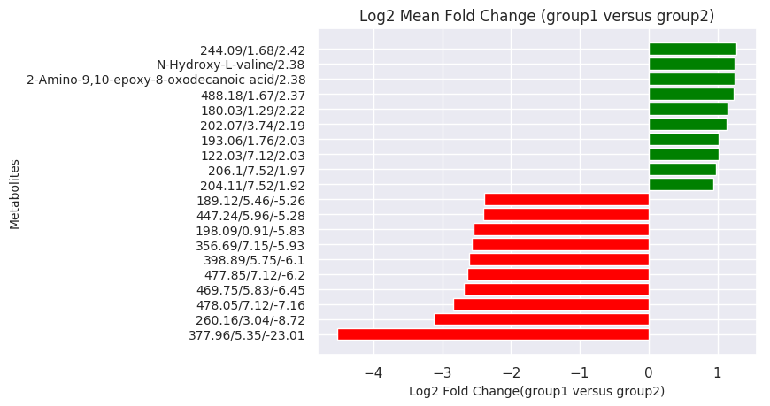

## Number of peaks before and after background subtraction (BS)

Number of peaks before and after background subtraction (BS) Number of peaks before and after BS

Showing <sup>6</sup>/<sub>6</sub> rows and <sup>2</sup>/<sub>2</sub> columns.

| Steps | Negative | Positive |
| --- | --- | --- |
| before_blank_subtraction | 3243.0 | 6233.0 |
| match_before_blank_subtraction | 94.0 | 149.0 |
| significant_match_before_blank_subtraction | 6.0 | 10.0 |
| after_blank_subtraction | 600.0 | 815.0 |
| match_after_blank_subtraction | 36.0 | 86.0 |
| significant_match_after_blank_subtraction | 4.0 | 8.0 |